# **Red Wine Quality EDA**

Turki Alsaedi, 16 Jun 2022 Table of Contents

### Introduction

In 2009, samples of white and red Vinho Verde wine were collected to predict human taste in wine and use it to improve its quality and, eventually, increase wine sales. These samples were divided into to datasets: red and white wine quality [1, 2]. In this report, we will examine the red wine dataset and apply exploratory data analysis (EDA) and data munging on it.

To ensure that the wine is safe to consume and is of high quality, wine certification is required. This certification is assessed by several tests including physicochemical tests [1]—which was used to describe the wine in this dataset. Physicochemical tests characterize wine using 12 input variables described in Table 1.

### The Dataset

| Variables | Unit | Description |
| --- | --- | --- |
| fixed.acidity | g/dm^3 | Most acids involved with wine or fixed or nonvolatile |
| volatile.acidity | g/dm^3 | The amount of acetic acid in wine, which at too high of levels can lead to an unpleasant, vinegar taste |
| citric.acid | g/dm^3 | Found in small quantities, citric acid can add ‘freshness’ and flavor to wines |
| residual.sugar | g/dm^3 | The amount of sugar remaining after fermentation stops, it’s rare to find wines with less than 1 gram/liter and wines with greater than 45 grams/liter are considered sweet |
| chlorides | g/dm^3 | The amount of salt in the wine |
| free.sulfur.dioxide | mg/dm^3 | The free form of SO2 exists in equilibrium between molecular SO2 (as a dissolved gas) and bisulfite ion; it prevents microbial growth and the oxidation of wine |
| total.sulfur.dioxide | mg/dm^3 | Amount of free and bound forms of S02; in low concentrations, SO2 is mostly undetectable in wine, but at free SO2 concentrations over 50 ppm, SO2 becomes evident in the nose and taste of wine |
| density | g/cm^3 | The density of water is close to that of water depending on the percent alcohol and sugar content |
| pH |  | Describes how acidic or basic a wine is on a scale from 0 (very acidic) to 14 (very basic); most wines are between 3-4 on the pH scale |
| sulphates | g/dm3 | A wine additive which can contribute to sulfur dioxide gas (S02) levels, wich acts as an antimicrobial and antioxidant |
| alcohol | % by volume | The percent alcohol content of the wine |
| quality |  | Wine quality (score between 0 and 10) |

Table 1: Red wine quality dataset input variables, units and their descriptions

The red wine quality dataset consists of 12 variables (columns) with 1,599 observations (rows). A sample of the dataset is shown in Table 2.

| fixed.acidity | volatile.acidity | citric.acid | residual.sugar | chlorides | free.sulfur.dioxide | total.sulfur.dioxide | density | pH | sulphates | alcohol | quality |
| --- | --- | --- | --- | --- | --- | --- | --- | --- | --- | --- | --- |
| 10.0 | 0.440 | 0.49 | 2.7 | 0.077 | 11 | 19 | 0.99630 | 3.23 | 0.63 | 11.6 | 7 |
| 10.4 | 0.440 | 0.42 | 1.5 | 0.145 | 34 | 48 | 0.99832 | 3.38 | 0.86 | 9.9 | 3 |
| 7.9 | 0.350 | 0.46 | 3.6 | 0.078 | 15 | 37 | 0.99730 | 3.35 | 0.86 | 12.8 | 8 |
| 7.2 | 0.695 | 0.13 | 2.0 | 0.076 | 12 | 20 | 0.99546 | 3.29 | 0.54 | 10.1 | 5 |
| 9.1 | 0.300 | 0.41 | 2.0 | 0.068 | 10 | 24 | 0.99523 | 3.27 | 0.85 | 11.7 | 7 |

Table 2: A sample of the dataset’s observations

### EDA

We will start the exploration by checking the correlations between the variables to check if there are any interesting findings.

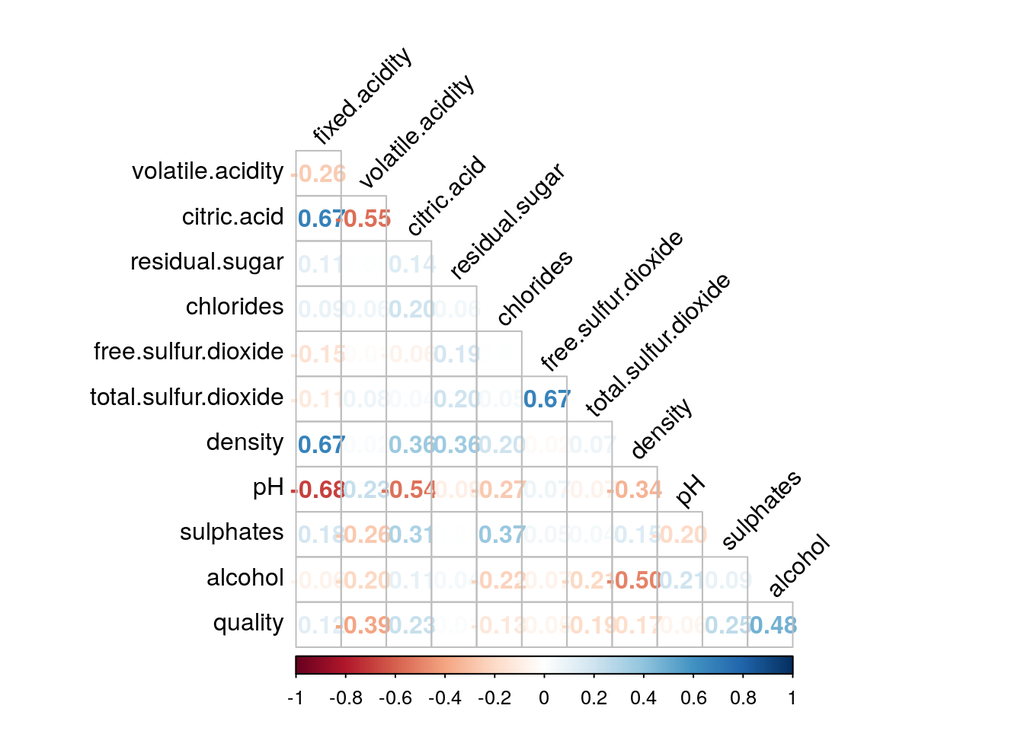

Figure 1: Correlation plot of all variables

Based on figure above, we can observe that there are 3 highly (>0.5) correlated variables and 4 are highly inversely correlated variables.

Correlated variables:

1. `density` / `fixed.acidity`
2. `citric.acid` / `fixed.acidity`
3. `total.sulfur.dioxide` / `free.sulfur.dioxide`

Inversely correlated variables:

1. `pH` / `fixed.acidityc` ✅
2. `citric.acid` / `volatile.acidity`
3. `pH` / `citric.acid` ✅
4. `alcohol` / `density`

Notes:

- `pH` inverse correlation with `fixed.acidity` and `citric.acid` is is not surprising since `pH` is a measure of acidity.
- **None of the variables have a any high correlation with the `quality` of the wine.**

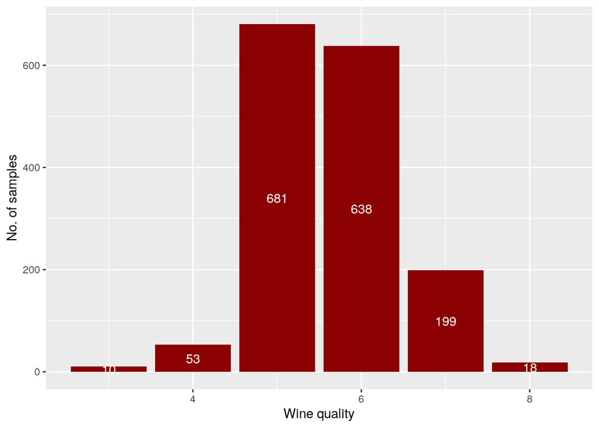

Figure 2: Number of wine samples based on its quality

From the figure we can see that:

- Samples quality range is [3-8]
- 95% of the samples fall in quality level of 5, 6 and 7

### References

[1] P. Cortez, A. Cerdeira, F. Almeida, T. Matos and J. Reis. Modeling wine preferences by data mining from physicochemical properties. In Decision Support Systems, Elsevier, 47(4):547-553, 2009.

[2] Cortez, Paulo, Cerdeira, A., Almeida, F., Matos, T. & Reis, J.. (2009). Wine Quality. UCI Machine Learning Repository.

### Source Code

This report is hosted on Github Pages and the repo can be accessed via [this link](https://github.com/Misk-DSI/individual-assignment-2-Turkinass).